# MIS 306 Data Analysis | Competition

## Forecasting

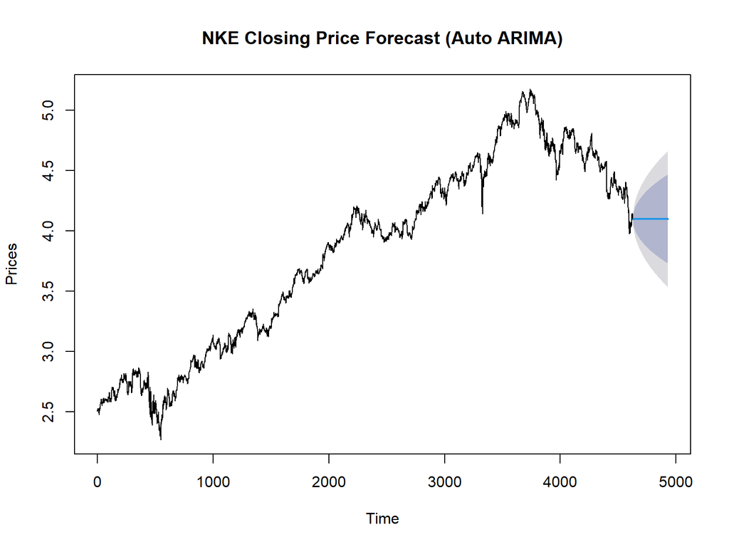

The forecast graph shows Nike’s future stock price predictions using the Auto ARIMA model. The black line represents historical prices, while the blue line shows the forecasted values. The shaded blue area indicates the prediction’s confidence range - wider areas mean more uncertainty. The forecast suggests prices will remain relatively stable with small fluctuations, neither sharply rising nor falling. However, the confidence band gradually widens over time, showing predictions become less certain further into the future. This is normal in stock forecasting. The model expects Nike’s prices to follow their recent pattern rather than making dramatic moves.